# Daynamica Summary Report

Daynamica Team

2026-10-20

# Overview

This report provides a collection of foundational tables and figures which summarize key details about this Daynamica dataset. This is meant to serve as a starting point for analyses and to help researchers identify areas for deeper exploration. The data used in this report has been preprocessed and cleaned prior to usage by this report. Certain analysis decisions were required to be prespecified. For instance, a key decision is the amount of data required for a day to be considered valid and to be included in the analysis. A common strategy is to require at least 12 or 16 hours of data be collected in a given day for that day to count as valid. The first table of the next section shows a summary related to this idea.

```r
library(plotly)
library(htmlwidgets)
library(sf)
library(geosphere)
library(gepaf)
library(sfdep)
library(dplyr)
library(data.table)

if (params$export_results) {
  output_location <- if (is.null(params$output_location)) getwd() else params$output_location
  result_location <- file.path(output_location, "results")
  if (!dir.exists(result_location)) {
    dir.create(result_location, recursive = TRUE)
  }
}

daynamica_data <- params$daynamica_data
options(dplyr.summarise.inform = FALSE)
```

# General Daynamica Summary Statistics

```r
if ("wide_ema_survey_table" %in% names(daynamica_data)) {
  total_ema_surveys <- daynamica_data$wide_ema_survey_table %>% nrow()
  days_with_at_least_1_ema_survey <- daynamica_data$wide_ema_survey_table %>% select(user_id, start_date) %>% distinct() %>% nrow()
} else {
  total_ema_surveys <- NA
  days_with_at_least_1_ema_survey <- NA
}
if ("wide_calendar_item_survey_table" %in% names(daynamica_data)) {
  total_cal_item_surveys <- daynamica_data$wide_calendar_item_survey_table %>% nrow()
  total_cal_item_surveys_without_duplicates <- sum(daynamica_data$ucal_items_temporal_plot_with_survey_data$survey_not_null, na.rm = TRUE)
} else {
  total_cal_item_surveys <- NA
  total_cal_item_surveys_without_duplicates <- NA
}


tibble("Unique Users" = daynamica_data$ucalitems_temporal_plot$user_id %>% unique() %>% length(),
       "Total Days of Data" = daynamica_data$ucalitems_temporal_plot %>%
                                select(user_id, start_date) %>%
                                distinct() %>% nrow(),
       "Total Unique Calendar Items" = daynamica_data$ucalitems_temporal_plot %>% nrow(),
       "Total EMA Surveys" = total_ema_surveys,
       "Days with at least 1 EMA Survey" = days_with_at_least_1_ema_survey,
       "Total Calendar Item Surveys (with Duplicates)" = total_cal_item_surveys,
       "Total Calendar Item Surveys (without Duplicates)" = total_cal_item_surveys_without_duplicates,
       "First Date of Data Collection" = daynamica_data$ucalitems_temporal_plot$start_date %>% min(),
       "Last Date of Data Collection" = daynamica_data$ucalitems_temporal_plot$start_date %>% max()) %>%
  mutate(temp = NA) %>%
  tidyr::pivot_longer(cols = -temp,
                      names_to = "Dataset Statsitics",
                      values_to = "Output",
                      values_transform = as.character) %>%
  select(-temp) %>%
  knitr::kable()
```

| Dataset Statsitics | Output |
| --- | --- |
| Unique Users | 96 |
| Total Days of Data | 820 |
| Total Unique Calendar Items | 8647 |
| Total EMA Surveys | NA |
| Days with at least 1 EMA Survey | NA |
| Total Calendar Item Surveys (with Duplicates) | NA |
| Total Calendar Item Surveys (without Duplicates) | NA |
| First Date of Data Collection | 2022-10-26 |
| Last Date of Data Collection | 2023-03-05 |

```r
participant_start_end_dates <-
  daynamica_data$ucalitems_temporal_plot %>%
  group_by(user_id) %>%
  dplyr::summarize(first_date = as.numeric(min(start_date)),
            last_date = as.numeric(max(start_date))) %>%
  arrange(first_date)

date_range <- min(participant_start_end_dates$first_date):max(participant_start_end_dates$last_date)
cumulative_participants <- rep(NA, length(date_range))
active_participants <- rep(NA, length(date_range))
for(i in 1:length(date_range)){
  cumulative_participants[i] <- participant_start_end_dates %>%
    filter(first_date <= date_range[i]) %>%
    nrow()

  active_participants[i] <- participant_start_end_dates %>%
    filter(first_date <= date_range[i],
           last_date >= date_range[i]) %>%
    nrow()
}
participant_data_plotting_data <-
  tibble(date_range,
         cumulative_participants,
         active_participants,
         clean_date = as.Date(date_range, origin = "1970-01-01"))
```

## Cummulative Enrollment Plot

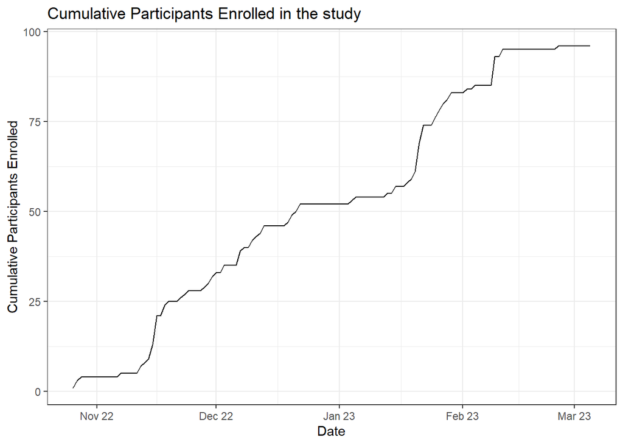

```r
participant_data_plotting_data %>%
  ggplot(aes(x = clean_date, y = cumulative_participants)) +
  geom_line() +
  ylab("Cumulative Participants Enrolled") +
  xlab("Date") +
  theme_bw()+
  scale_x_date(date_labels = "%b %y") +
  ggtitle("Cumulative Participants Enrolled in the study")
```

## Active Participant Plot

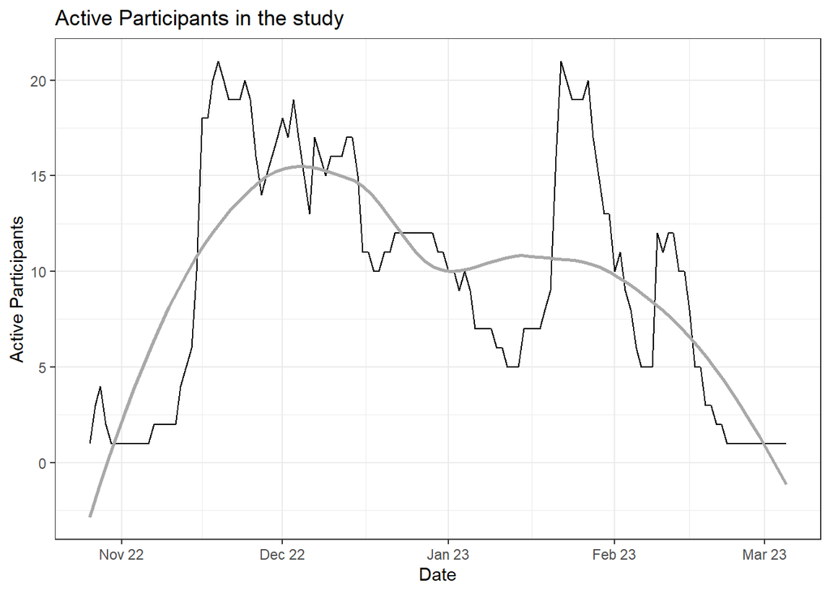

```r
participant_data_plotting_data %>%
  ggplot(aes(x = clean_date, y = active_participants)) +
  geom_line() +
  ylab("Active Participants") +
  xlab("Date") +
  theme_bw()+
  scale_x_date(date_labels = "%b %y") +
  geom_smooth(se = F, color = "darkgrey", method = "loess") +
  ggtitle("Active Participants in the study")
```

## Duration of Data Collection

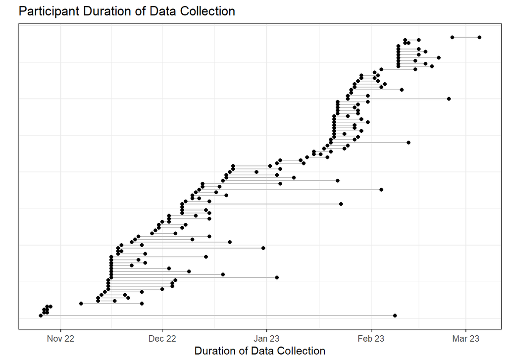

```r
participant_start_end_dates %>%
  dplyr::mutate(row_number = row_number()) %>%
  dplyr::mutate(first_date = as.Date(first_date, origin = "1970-01-01"),
                last_date = as.Date(last_date,  origin = "1970-01-01")) %>%
  ggplot(aes(y = row_number)) +
  geom_segment(aes(x = first_date, xend = last_date,
                   y = row_number, yend = row_number), col = "grey") +
    geom_point(aes(x = first_date,
                    y = row_number), col = "black") +
    geom_point(aes(x = last_date,
                    y = row_number), col = "black") +
      theme_bw() +
  ylab("") +
  scale_x_date(date_labels = "%b %y") +
  xlab("Duration of Data Collection") +
  ggtitle("Participant Duration of Data Collection") +
  theme(axis.text.y = element_blank(),
        axis.ticks.y = element_blank())
```

## Distribution of Data per User

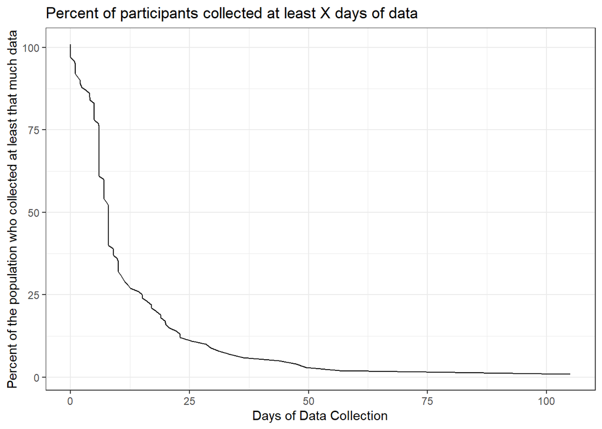

```r
temp <-
  participant_start_end_dates %>%
  dplyr::mutate(duration = last_date - first_date)
duration_percentile = quantile(temp$duration, probs = seq(0, 1, by = 0.01))
tibble(perc_rank = as.numeric(gsub("%","" , names(duration_percentile))),
       duration_percentile
) %>%
  ggplot(aes(x = duration_percentile, y = 1-perc_rank + 100)) +
  geom_line() +
  xlab("Days of Data Collection") +
  ylab("Percent of the population who collected at least that much data") +
  theme_bw()+
  ggtitle("Percent of participants collected at least X days of data")
```

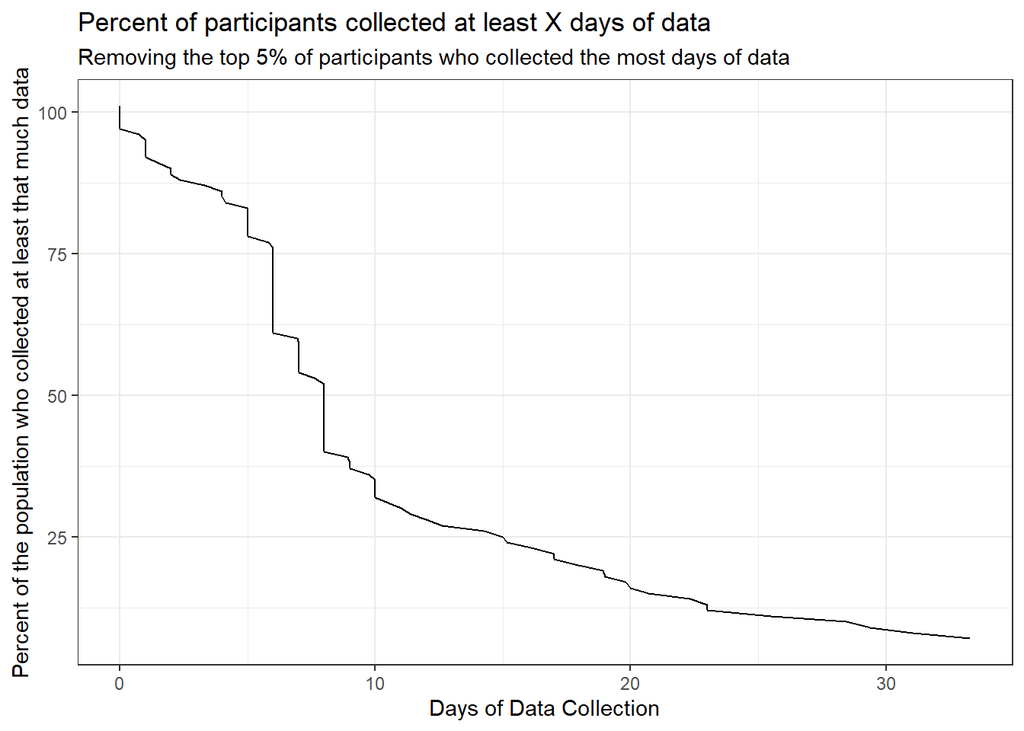

```r
tibble(perc_rank = as.numeric(gsub("%","" , names(duration_percentile))),
       duration_percentile
) %>%
  filter(perc_rank < 95) %>%
  ggplot(aes(x = duration_percentile, y = 1-perc_rank + 100)) +
  geom_line() +
  xlab("Days of Data Collection") +
  ylab("Percent of the population who collected at least that much data") +
  theme_bw() +
  ggtitle("Percent of participants collected at least X days of data",
          "Removing the top 5% of participants who collected the most days of data")
```

# Quantity of Daynamica Data

This table provides information on the number of days of data which were collected within the study. The totals are stratified by day of the week as well as overall. The remaining columns outline the percentage of days which have at least that many hours of data. It should be noted that prior to the analysis, a filter exists to specify how many hours must be collected for a day to be considered valid. This filter may be modified in the data preparation steps prior to generating this report. More restrictive filtering may result in higher quality but fewer days while less restrictive filtering will result in more days being included in the analysis. Our current recommendation is to use a filter somewhere between 12-16 hours of data per person as a requirement.

```r
temp_table <-
  rDaynamica::count_valid_per_days(day_summary = daynamica_data[['day_summary']],
                       numerator_col = 'with_subtype',
                       denominator_filter = 'interact_by_confirm>0') %>%
  mutate(`Day of the Week` = ifelse(`Day of the Week` == "Total", "All Days", `Day of the Week`))
temp_table %>%
  knitr::kable()
```

| Day of the Week | Total # of Days | 24 hours | 20 hours | 16 hours | 12 hours | 8 hours |
| --- | --- | --- | --- | --- | --- | --- |
| Monday | 97 | 66 (68.0%) | 85 (87.6%) | 92 (94.8%) | 97 (100.0%) | 97 (100.0%) |
| Tuesday | 106 | 74 (69.8%) | 87 (82.1%) | 99 (93.4%) | 106 (100.0%) | 106 (100.0%) |
| Wednesday | 109 | 75 (68.8%) | 84 (77.1%) | 91 (83.5%) | 109 (100.0%) | 109 (100.0%) |
| Thursday | 113 | 85 (75.2%) | 95 (84.1%) | 98 (86.7%) | 113 (100.0%) | 113 (100.0%) |
| Friday | 99 | 62 (62.6%) | 75 (75.8%) | 86 (86.9%) | 99 (100.0%) | 99 (100.0%) |
| Saturday | 97 | 60 (61.9%) | 74 (76.3%) | 79 (81.4%) | 97 (100.0%) | 97 (100.0%) |
| Sunday | 101 | 78 (77.2%) | 85 (84.2%) | 91 (90.1%) | 101 (100.0%) | 101 (100.0%) |
| All Days | 722 | 500 (69.3%) | 585 (81.0%) | 636 (88.1%) | 722 (100.0%) | 722 (100.0%) |

```r
if(params$export_results){
  write.csv(temp_table, file = paste0(result_location, "/Quantity_of_Daynamica_Data.csv"), row.names = F)
}
```

# Visualizing Participant Summaries

A quintessential first task when exploring Daynamica data is to begin with examining the sequential patterns of activities in trips across multiple days. The visualizations provided below highlight one such method of exploration. Using these visualizations, we may assess the patterns within and between days in how participants engaged in activities and trips. The taller segments represent Activities and the narrow (often shorter in duration) segments represent Trips. Each segment is colored to identify which type of Activity or Trip it represents.

For a more robust review of these plots, use the *Calendar Item Visualization Module*. Alternatively, these plots are made using the function *generate_time_of_day_plot*. Interested researchers may utilize this function directly or create their own to fit their specific needs.

```r
library(lubridate)
```

```r
library(ggnewscale)
library(wesanderson)

unique_activity_labels <-
  daynamica_data$ucalitems_temporal_plot %>%
  tibble() %>%
  filter(type_decoded == "ACTIVITY") %>%
  pull(subtype_decoded) %>% unique()
unique_trip_labels <-
  daynamica_data$ucalitems_temporal_plot %>%
  tibble() %>%
  filter(type_decoded == "TRIP") %>%
  pull(subtype_decoded) %>% unique()

activity_palette <- c(wes_palette("Zissou1", 1),
                      wes_palette("Zissou1", 5)[4:5],
                      rev(wes_palette("Royal1", 4)[2:4]),
                      wes_palette("Moonrise3", 2),
                      wes_palette("GrandBudapest2"),
                      wes_palette("GrandBudapest1"),
                      wes_palette("Chevalier1", 4))[1:length(unique_activity_labels)]


trip_palette <- c(palette.colors(n = 8, "ggplot2")[-1],
                  palette.colors(n = 8, "alphabet"))[1:length(unique_trip_labels)]


color_codes_activity_data <- data.frame(labels = unique_activity_labels,
                                   values = activity_palette)

color_codes_trips_data <- data.frame(labels = unique_trip_labels,
                                values = trip_palette)
```

```r
user_id_list = params$user_id_list

user_id_list_labels <- gsub("@", "at", user_id_list)


if(!is.null(user_id_list)){
  if(params$export_results & !dir.exists(paste0(result_location,"/day_level_visualizations"))){
  dir.create(paste0(result_location,"/day_level_visualizations"))
    }
 for(i in 1:length(user_id_list)){
 cat(paste0("\n\n## ", "Participant: ", user_id_list_labels[i], "\n"))
  p <- suppressMessages(rDaynamica::generate_time_of_day_plot(daynamica_data$ucalitems_temporal_plot %>%
                              as_tibble() %>%
                              filter(user_id == user_id_list[i]),
                            color_codes_activity = color_codes_activity_data,
                            color_codes_trips = color_codes_trips_data))
  print(p)


  if(params$export_results){
    ggsave(filename = paste0(result_location,paste0("/day_level_visualizations/",  user_id_list[i], "_plot.png")), p,
                             device = png, width = 20, heigh = 20, dpi = 450)

}
 }
}
```

## Participant: user_id_122

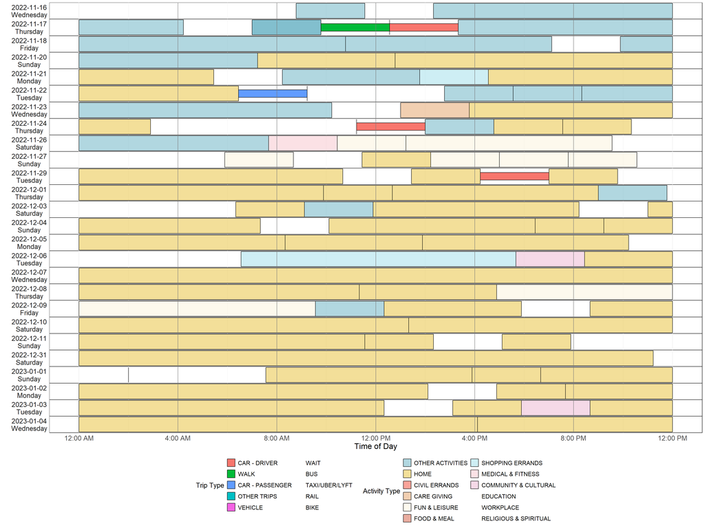

## Participant: user_id_125

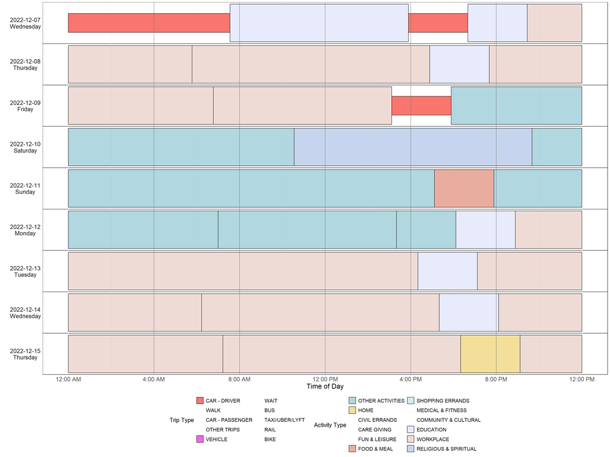

# Day Level Summary Statistics

This section provides collections of summary tables and figures pertaining to different key characteristics within a Daynamica dataset.

```r
daynamica_data[['leg2trip']] = rDaynamica::leg2trip(daynamica_data[['ucalitems_temporal_plot']], criterion = 'distance')
```

## Counts per Day

This table provides day level summary statistics. For each category, the Median, Mean, SD, Min and Max are provided. These summary statistics are computed on the per day level. See the Weekday vs Weekend Breakdown tab for a stratified tabulation. For a detailed description of the specific statistics, see our Daynamica User Guide,

### All Data

```r
temp_table <- rDaynamica::overview_statistics(csv_dict = daynamica_data, stat_group_cols = c('Statistics'))

temp_table%>%
  knitr::kable(digits = 2)
```

| Statistics | Median | Mean | SD | Min | Max |
| --- | --- | --- | --- | --- | --- |
| Recorded Data per Day (Minutes) | 1440 | 1367.71 | 306.93 | 720 | 5760.00 |
| Total Activity Duration per Day (Minutes) | 1440 | 1297.57 | 332.20 | 0 | 5760.00 |
| Total Trip Duration per Day (Minutes) | 0 | 70.14 | 136.74 | 0 | 1440.00 |
| Total Trip Distance per Day (Miles) | 0 | 5.09 | 22.89 | 0 | 355.21 |
| Activity Count per Day | 5 | 5.81 | 3.70 | 0 | 26.00 |
| Trip (Segment) Count per Day | 3 | 4.13 | 4.15 | 0 | 32.00 |
| Trip (Complete) Count per Day | 3 | 3.78 | 3.64 | 0 | 22.00 |

```r
if(params$export_results){
  write.csv(temp_table, file = paste0(result_location,"/Aggregate Day Level Statsitics.csv"), row.names = F)
}
```

### Weekday vs Weekend Breakdown

```r
temp_table <-
  rDaynamica::overview_statistics(csv_dict = daynamica_data,
                    stat_group_cols = c('IsWeekend','Statistics'))%>%
  mutate(IsWeekend = ifelse(IsWeekend == T, "Weekend", "Weekday"))

temp_table %>%
  knitr::kable(digits = 2)
```

| IsWeekend | Statistics | Median | Mean | SD | Min | Max |
| --- | --- | --- | --- | --- | --- | --- |
| Weekday | Recorded Data per Day (Minutes) | 1440.00 | 1380.47 | 335.84 | 720.00 | 5760.00 |
| Weekend | Recorded Data per Day (Minutes) | 1440.00 | 1333.75 | 208.46 | 720.00 | 1440.00 |
| Weekday | Total Activity Duration per Day (Minutes) | 1436.67 | 1304.38 | 361.05 | 0.00 | 5760.00 |
| Weekend | Total Activity Duration per Day (Minutes) | 1440.00 | 1279.43 | 238.80 | 453.33 | 1440.00 |
| Weekday | Total Trip Duration per Day (Minutes) | 0.00 | 76.09 | 148.97 | 0.00 | 1440.00 |
| Weekend | Total Trip Duration per Day (Minutes) | 0.00 | 54.32 | 95.50 | 0.00 | 333.33 |
| Weekday | Total Trip Distance per Day (Miles) | 0.00 | 5.16 | 24.17 | 0.00 | 355.21 |
| Weekend | Total Trip Distance per Day (Miles) | 0.00 | 4.90 | 19.11 | 0.00 | 243.10 |
| Weekday | Activity Count per Day | 5.00 | 5.95 | 3.74 | 0.00 | 26.00 |
| Weekend | Activity Count per Day | 5.00 | 5.46 | 3.59 | 1.00 | 20.00 |
| Weekday | Trip (Segment) Count per Day | 3.00 | 4.20 | 4.13 | 0.00 | 32.00 |
| Weekend | Trip (Segment) Count per Day | 3.00 | 3.93 | 4.19 | 0.00 | 21.00 |
| Weekday | Trip (Complete) Count per Day | 3.00 | 3.84 | 3.59 | 0.00 | 22.00 |
| Weekend | Trip (Complete) Count per Day | 3.00 | 3.63 | 3.78 | 0.00 | 19.00 |

```r
if(params$export_results){
  write.csv(temp_table, file = paste0(result_location,"/Aggregate Day Level Statsitics stratified by day of week.csv"), row.names = F)
}
```

## Trip Summary Statistics

This section focuses on Trip level summary statistics. The data is organized across a number of factors. Along the rows, different trip modalities are listed. Along the columns the total unique trip counts, trip durations in minutes, and trip distances in miles traveled are listed. All units are standardized as totals per day. The columns are further stratified by day of the week groupings: All days, Weekdays only and Weekends only.

Alongside the summary table, interactive visualizations are included to highlight the different totals presented in the summary table.

### Summary Table

```r
temp_table <- rDaynamica::activity_trip(ucalitems=daynamica_data[['ucalitems_temporal_plot']],
                      day_summary=daynamica_data[['day_summary']],
                      mytype='TRIP',
                      trip_num=-1)
temp_table[-which(temp_table[,1] == "Total"),] %>%
  arrange(subtype_decoded   ) %>%
  bind_rows(temp_table[which(temp_table[,1] == "Total"),])  %>%
  knitr::kable(digits = 2)
```

| subtype_decoded | Trip Counts_All Days | Trip Counts_Weekday | Trip Counts_Weekend | Trip Duration in Minutes_All Days | Trip Duration in Minutes_Weekday | Trip Duration in Minutes_Weekend | Trip Distance in Miles_All Days | Trip Distance in Miles_Weekday | Trip Distance in Miles_Weekend |
| --- | --- | --- | --- | --- | --- | --- | --- | --- | --- |
| BIKE | 0.03 | 0.03 | 0.02 | 0.41 | 0.56 | 0.00 | 0.00 | 0.00 | 0.00 |
| BUS | 0.23 | 0.28 | 0.10 | 3.86 | 4.19 | 2.98 | 0.12 | 0.13 | 0.09 |
| CAR - DRIVER | 1.49 | 1.47 | 1.54 | 25.35 | 28.17 | 17.86 | 1.82 | 1.82 | 1.82 |
| CAR - PASSENGER | 0.60 | 0.58 | 0.64 | 13.82 | 14.54 | 11.90 | 1.05 | 1.02 | 1.13 |
| OTHER TRIPS | 0.10 | 0.11 | 0.08 | 1.38 | 1.62 | 0.74 | 0.02 | 0.01 | 0.04 |
| RAIL | 0.07 | 0.08 | 0.04 | 0.81 | 1.12 | 0.00 | 0.03 | 0.04 | 0.00 |
| TAXI/UBER/LYFT | 0.05 | 0.05 | 0.06 | 0.81 | 0.84 | 0.74 | 0.05 | 0.05 | 0.05 |
| VEHICLE | 0.69 | 0.68 | 0.71 | 10.93 | 11.68 | 8.93 | 1.95 | 2.03 | 1.73 |
| WAIT | 0.15 | 0.16 | 0.11 | 3.84 | 4.72 | 1.49 | 0.01 | 0.01 | 0.00 |
| WALK | 0.73 | 0.76 | 0.66 | 8.93 | 8.65 | 9.67 | 0.04 | 0.04 | 0.04 |
| Total | 4.13 | 4.20 | 3.93 | 70.14 | 76.09 | 54.32 | 5.09 | 5.16 | 4.90 |

```r
if(params$export_results){
  write.csv(temp_table, file = paste0(result_location, "/Trip Count Summary Table - Trip Subcomponent.csv"), row.names = F)
}
```

### Trip Count Figure

```r
rDaynamica::activity_trip_figure(ucalitems=daynamica_data[['leg2trip']],
                             tb = 'leg2trip',
                             day_summary=daynamica_data[['day_summary']],
                             mytype='TRIP',
                             directory = 'Results',
                             agg_col='id')
```

[interactive chart not shown]

### Trip Duration Figure

```r
rDaynamica::activity_trip_figure(ucalitems=daynamica_data[['leg2trip']],
                             tb = 'leg2trip',
                             day_summary=daynamica_data[['day_summary']],
                             mytype='TRIP',
                             directory = 'Results',
                             agg_col='duration_after_split')
```

[interactive chart not shown]

### Trip Distance Figure

```r
rDaynamica::activity_trip_figure(ucalitems=daynamica_data[['leg2trip']],
                             tb = 'leg2trip',
                             day_summary=daynamica_data[['day_summary']],
                             mytype='TRIP',
                             directory = 'Results',
                             agg_col='distance_after_split')
```

[interactive chart not shown]

## Primary Mode Summary Statistics

This section focuses on tabulating results based on the Primary travel model. The Primary Travel Mode is defined as the travel mode in which you traveled the farthest distance during a trip.

### Summary Table

```r
data <- daynamica_data$ucalitems_temporal_plot

temporary_table <- data %>%
  tibble() %>%
  arrange(user_id,
          start_date,
          start_timestamp) %>%
  mutate(activity_indicator = ifelse(type_decoded == "ACTIVITY", 1, 0)) %>%
  mutate(trip_id = cumsum(activity_indicator)) %>%
  select(id, user_id, start_date,
         start_time, end_time,
         type_decoded, subtype_decoded,
         trip_purpose, trip_id,
         distance_after_split, duration_after_split,
         IsWeekend) %>%
  filter(type_decoded == "TRIP") %>%
  group_by(user_id, type_decoded, start_date, trip_id, IsWeekend) %>%
  mutate(is_max_distance = ifelse(distance_after_split == max(distance_after_split), 1, 0)) %>%
  mutate(primary_mode = as.character(case_when(is_max_distance == 1 ~ subtype_decoded))) %>%
  mutate(primary_mode = ifelse(is.na(primary_mode), "", primary_mode)) %>%
  mutate(distance_after_split = sum(distance_after_split, na.rm = T),
         duration_after_split = sum(duration_after_split, na.rm = T)) %>%
  filter(is_max_distance == 1) %>%
  distinct() %>%
  data.table()

temp_table <- rDaynamica::activity_trip(ucalitems=temporary_table,
                      day_summary=daynamica_data[['day_summary']],
                      by_field = "primary_mode",
                      mytype='TRIP',
                      trip_num=-1)
temp_table[-which(temp_table[,1] == "Total"),] %>%
  arrange(primary_mode  ) %>%
  bind_rows(temp_table[which(temp_table[,1] == "Total"),])  %>%
  knitr::kable(digits = 2)
```

| primary_mode | Trip Counts_All Days | Trip Counts_Weekday | Trip Counts_Weekend | Trip Duration in Minutes_All Days | Trip Duration in Minutes_Weekday | Trip Duration in Minutes_Weekend | Trip Distance in Miles_All Days | Trip Distance in Miles_Weekday | Trip Distance in Miles_Weekend |
| --- | --- | --- | --- | --- | --- | --- | --- | --- | --- |
| BIKE | 0.02 | 0.03 | 0.01 | 1.02 | 1.40 | 0.00 | 0.00 | 0.00 | 0.00 |
| BUS | 0.22 | 0.26 | 0.10 | 4.07 | 4.47 | 2.98 | 0.12 | 0.13 | 0.09 |
| CAR - DRIVER | 1.46 | 1.45 | 1.50 | 25.96 | 29.00 | 17.86 | 1.83 | 1.83 | 1.82 |
| CAR - PASSENGER | 0.57 | 0.55 | 0.61 | 14.02 | 14.82 | 11.90 | 1.05 | 1.02 | 1.13 |
| OTHER TRIPS | 0.10 | 0.11 | 0.08 | 1.38 | 1.62 | 0.74 | 0.02 | 0.01 | 0.04 |
| RAIL | 0.06 | 0.07 | 0.04 | 1.02 | 1.40 | 0.00 | 0.03 | 0.04 | 0.00 |
| TAXI/UBER/LYFT | 0.05 | 0.05 | 0.06 | 0.81 | 0.84 | 0.74 | 0.05 | 0.05 | 0.05 |
| VEHICLE | 0.67 | 0.66 | 0.70 | 10.72 | 11.40 | 8.93 | 1.94 | 2.02 | 1.73 |
| WAIT | 0.14 | 0.15 | 0.11 | 4.85 | 6.12 | 1.49 | 0.01 | 0.01 | 0.00 |
| WALK | 0.70 | 0.73 | 0.62 | 9.13 | 8.93 | 9.67 | 0.04 | 0.04 | 0.04 |
| Total | 3.98 | 4.05 | 3.81 | 72.98 | 80.00 | 54.32 | 5.09 | 5.16 | 4.90 |

```r
if(params$export_results){
  write.csv(temp_table, file = paste0(result_location, "/Trip Summary Table - Primary Mode.csv"), row.names = F)
}
```

## Activity Summary Statistics

This section focuses on Activity level summary statistics.

### Summary Table

```r
temp_table <- rDaynamica::activity_trip(ucalitems=daynamica_data[['ucalitems_temporal_plot']],
                      day_summary=daynamica_data[['day_summary']],
                      mytype='ACTIVITY',
                      trip_num=-1)

temp_table[-which(temp_table[,1] == "Total"),] %>%
  arrange(subtype_decoded ) %>%
  bind_rows(temp_table[which(temp_table[,1] == "Total"),])  %>%
  knitr::kable(digits = 2)
```

| subtype_decoded | Activity Counts_All Days | Activity Counts_Weekday | Activity Counts_Weekend | Activity Duration in Hours_All Days | Activity Duration in Hours_Weekday | Activity Duration in Hours_Weekend |
| --- | --- | --- | --- | --- | --- | --- |
| CARE GIVING | 0.10 | 0.09 | 0.12 | 0.48 | 0.41 | 0.64 |
| CIVIL ERRANDS | 0.04 | 0.04 | 0.03 | 0.05 | 0.07 | 0.01 |
| COMMUNITY & CULTURAL | 0.11 | 0.11 | 0.14 | 0.27 | 0.26 | 0.31 |
| EDUCATION | 0.17 | 0.21 | 0.06 | 0.42 | 0.49 | 0.22 |
| FOOD & MEAL | 0.33 | 0.34 | 0.33 | 0.42 | 0.37 | 0.56 |
| FUN & LEISURE | 0.27 | 0.25 | 0.35 | 1.20 | 1.30 | 0.96 |
| HOME | 1.96 | 1.95 | 1.99 | 12.22 | 11.84 | 13.22 |
| MEDICAL & FITNESS | 0.23 | 0.28 | 0.12 | 0.44 | 0.50 | 0.29 |
| OTHER ACTIVITIES | 1.32 | 1.34 | 1.27 | 2.41 | 2.37 | 2.51 |
| RELIGIOUS & SPIRITUAL | 0.05 | 0.04 | 0.07 | 0.18 | 0.15 | 0.25 |
| SHOPPING ERRANDS | 0.46 | 0.41 | 0.58 | 0.72 | 0.67 | 0.84 |
| WORKPLACE | 0.77 | 0.90 | 0.41 | 2.82 | 3.30 | 1.52 |
| Total | 5.81 | 5.95 | 5.46 | 21.63 | 21.74 | 21.32 |

```r
if(params$export_results){
  write.csv(temp_table, file = paste0(result_location, "/Activity Count Summary Table .csv"), row.names = F)
}
```

### Activity Count Figure

```r
rDaynamica::activity_trip_figure(ucalitems=daynamica_data[['leg2trip']],
                             tb = 'leg2trip',
                             day_summary=daynamica_data[['day_summary']],
                             mytype='ACTIVITY',
                             directory = 'Results',
                             agg_col='id')
```

[interactive chart not shown]

### Activity Duration Figure

```r
rDaynamica::activity_trip_figure(ucalitems=daynamica_data[['leg2trip']],
                             tb = 'leg2trip',
                             day_summary=daynamica_data[['day_summary']],
                             mytype='ACTIVITY',
                             directory = 'Results',
                             agg_col='duration_after_split')
```

[interactive chart not shown]

## Trip Purpose Summary Statistics

### Summary Table

```r
temp_table <- rDaynamica::activity_trip(ucalitems=daynamica_data[['ucalitems_temporal_plot']],
                      day_summary=daynamica_data[['day_summary']],
                      mytype='TRIP',
                      trip_num=-1,
              by_field = "trip_purpose")
temp_table[-which(temp_table[,1] == "Total"),] %>%
  arrange(trip_purpose) %>%
  bind_rows(temp_table[which(temp_table[,1] == "Total"),])  %>%
  knitr::kable(digits = 2)
```

| trip_purpose | Trip Counts_All Days | Trip Counts_Weekday | Trip Counts_Weekend | Trip Duration in Minutes_All Days | Trip Duration in Minutes_Weekday | Trip Duration in Minutes_Weekend | Trip Distance in Miles_All Days | Trip Distance in Miles_Weekday | Trip Distance in Miles_Weekend |
| --- | --- | --- | --- | --- | --- | --- | --- | --- | --- |
| CARE GIVING | 0.06 | 0.05 | 0.09 | 0.81 | 1.12 | 0.00 | 0.05 | 0.07 | 0.00 |
| CIVIL ERRANDS | 0.04 | 0.05 | 0.02 | 1.00 | 1.38 | 0.00 | 0.02 | 0.02 | 0.00 |
| COMMUNITY & CULTURAL | 0.10 | 0.09 | 0.12 | 1.42 | 1.40 | 1.49 | 0.10 | 0.09 | 0.14 |
| EDUCATION | 0.14 | 0.17 | 0.03 | 2.59 | 3.28 | 0.74 | 0.09 | 0.08 | 0.10 |
| FOOD & MEAL | 0.29 | 0.30 | 0.27 | 3.25 | 3.36 | 2.98 | 0.19 | 0.08 | 0.49 |
| FUN & LEISURE | 0.16 | 0.13 | 0.24 | 1.83 | 1.40 | 2.98 | 0.07 | 0.09 | 0.02 |
| HOME | 1.09 | 1.09 | 1.10 | 15.80 | 16.43 | 14.14 | 0.88 | 0.68 | 1.44 |
| MEDICAL & FITNESS | 0.24 | 0.29 | 0.12 | 5.28 | 6.71 | 1.49 | 0.19 | 0.23 | 0.09 |
| OTHER ACTIVITIES | 0.94 | 0.93 | 0.96 | 15.65 | 15.94 | 14.88 | 1.86 | 2.23 | 0.87 |
| RELIGIOUS & SPIRITUAL | 0.04 | 0.03 | 0.06 | 0.61 | 0.56 | 0.74 | 0.04 | 0.02 | 0.11 |
| SHOPPING ERRANDS | 0.40 | 0.36 | 0.52 | 7.52 | 7.83 | 6.70 | 0.28 | 0.31 | 0.19 |
| UNKNOWN | 0.09 | 0.10 | 0.08 | 4.65 | 5.56 | 2.23 | 0.18 | 0.22 | 0.06 |
| WORKPLACE | 0.55 | 0.63 | 0.32 | 9.72 | 11.13 | 5.95 | 1.14 | 1.05 | 1.38 |
| Total | 4.13 | 4.20 | 3.93 | 70.14 | 76.09 | 54.32 | 5.09 | 5.16 | 4.90 |

```r
if(params$export_results){
  write.csv(temp_table, file = paste0(result_location, "/Trip Purpose Count Summary Table.csv"), row.names = F)
}
```